# TIPOLOGÍA I CICLE DE VIDA DE LES DADES. Informe Dinàmic PRACTICA2

Joaquim de Dalmases Juanet

20 de mayo de 2019

Activitat 3: Modelització predictiva

```r
# Carreguem les llibreries que s'utilitzaran a la PAC 2, evitant escriure en l'informe els
# missatges o alertes que es produeixin [{r, message=F, warning=F}].

library(kableExtra)   #  Generar taules formatejades en el informe en markdown.
library(stringr)      #  Manipulació de text. En concret per fer reemplaçaments de parts de text.
library(Hmisc)        #  Visualització d'histogrames.
library(car)          #  Q-Q plots.
library(dplyr)        #  Manipulació de datasets i  data.frames.
library(pROC)         #  Representar i calcular corbes ROC i AUROC.
library(corrplot)     #  Aplicar index de correlació de Pearson.
```

**DEFINIR EL DIRECTORI DE TREBALL.**

```r
# Fixem la carpeta o directori treball. Serà el suposat si s'omiteix la ruta origen o destí d'un fitxer.
# Localització del fitxer de fonts de dades 'rawData.csv'.
setwd("D:/_UOC/CursMaster/11-Tipologia_i_Cicle_de_Vida_de_Dades/PRACTICA_2/codi/codiH/Practica2")
```

**CARREGAR ELS ARXIUS DE DADES A L’ENTORN DE TREBALL DE R (R STUDIO) - winequality-red.csv i winequality-white.csv**

```r
# Lectura del fitxer amb la funció 'read.csv' perque visualitzats els separadors es la que
# per defecte ja té definits els paràmetres més correctes.
# El contingut queda en una variable data.frame (d).
nom1<-"winequality-red.csv"
nom2<-"winequality-white.csv"
n1<-read.csv(file.path(getwd(),nom1), sep=";", encoding="UTF-8")
n2<-read.csv(file.path(getwd(),nom2), sep=";", encoding="UTF-8")
# Observem que els fitxers originals tenen iguals capçaleres i podrem combinar els 2 datasets.

# Comprovació de la bona lectura/transferència de dades, visualitzant una mostra de 6 linies o registres.
# Amb el segon parametre de l'ordre 'head', podem definir el nº de linies desitjat, per defecte 2.
head(n1,2)
```

```
##   fixed.acidity volatile.acidity citric.acid residual.sugar chlorides
## 1           7.4             0.70           0            1.9     0.076
## 2           7.8             0.88           0            2.6     0.098
##   free.sulfur.dioxide total.sulfur.dioxide density   pH sulphates alcohol
## 1                  11                   34  0.9978 3.51      0.56     9.4
## 2                  25                   67  0.9968 3.20      0.68     9.8
##   quality
## 1       5
## 2       5
```

```r
head(n2,2)
```

```
##   fixed.acidity volatile.acidity citric.acid residual.sugar chlorides
## 1           7.0             0.27        0.36           20.7     0.045
## 2           6.3             0.30        0.34            1.6     0.049
##   free.sulfur.dioxide total.sulfur.dioxide density  pH sulphates alcohol
## 1                  45                  170   1.001 3.0      0.45     8.8
## 2                  14                  132   0.994 3.3      0.49     9.5
##   quality
## 1       6
## 2       6
```

## 1. DESCRIPCIÓ DEL DATASET.

**1. DESCRIPCIÓ DEL DATASET. PERQUÈ ÉS IMPORTANT I QUINA PREGUNTA PRETÉN RESPONDRE?**

El dataset ‘Red Wine’ emmagatzema les característiques fisico-químiques de les mostres de vi blanc i negre junt amb el ratio de la qualitat otorgada, en una escala de 0 a 10. Conté 1599 mostres de vi “Vinho Verde”, **negre** i 4898 de <b<blanc, de la zona nord de Portugal. Cada mostra de vi té assignada un valor de qualitat resultats de proves realitzades en la seva composició (tests de quantitat d’alcohol, nivell d’acidesa, contingut residual de sucres etc…). En total són 12 atributs descrivint característiques entre fisicoquímiques i la classificació de qualitat de la mostra.

Emprearem aquest dataset per respondre a la pregunta de **quínes característiques principals defineixen un vi de qualitat?. Cercarem si aquestes canvien segons el color del vi, negre o blanc.**

Infromació a tenir en compte:  
‘Vinho verde’ és un producte únic de la regió de Minho (nord-oest) de Portugal. Es apreciat per les característiques: Alcohol grau mig, i especialment per la seva frescor.

Descripció dels atributs o camps del datatset:

- **fixed.acidity** (Acidesa fixe) [Unitats: g(tartaric acid)/l]: És la quantitat d’àcidesa que no s’evapora i per tant resta fixe al vi.
- **volatile.acidity** (Acidesa volàtil)[Unitats: g(acetic acid)/l]: La quantitat en excès d’àcid acètic en vi, pot afegir sabor amarg o avinagrat, si les quantitats són altes.
- **citric.acid** (Àcid cítric) [Unitats: g/l]: trobat en petites quantitas, l’àcid cítric pot afegir frescor i sabor als vins.
- **residual.sugar** (Sucre residual) [Unitats: g/l]: Quantitat de sucre derivada del procés de fermentació (normalment trobem més de 1 gr/litre i si supera els 45grm./litre considerem el vi dolç.
- **chlorides** (Clorurs) [Unitats: g(sodium chloride)/l]: la quantitat de sal del vi
- **free.sulfur.dioxide** (Diòxid de sofre) [Unitats: mg/l]: Prevé el creixement microbià i l’oxidació del vi (anti-oxidant). Els vins blancs mantenen millor l’aspecte de vi jove. La normativa de la Comunitat Europea obliga des de l’any 2005 que qualsevol aliment o beguda que contingui més de 10 mg/l de sulfits ha de portar-ho en l’etiqueta com advertència. El motiu és que aquest additiu té capacitat al·lèrgena, és a dir, un petit percentatge de la població pot ser sensible o al·lèrgic als sulfits
- **total.sulfur.dioxide** (Diòxide de sofre (lliure i unit) [Unitats: mg/l]: concentracions per sobre de 50 ppm, Es detecta per olfacte i tast. Les quantitats excessives de SO2 poden inhibir la fermentació i causar efectes sensorials indesitjables.
- **density** (Densitat) [Unitats: g/dl]: serà propera a la de l’aigua (0.997 g/dl) i variaria segons les quantitats de sucre i alcohol, segons la qualitat de la fermentació.
- **pH** (pH): descriu com un vi àcid o bàsic és a una escala de 0 (molt àcida) a 14 (molt bàsica); la majoria dels vins tenen entre 3-4 a l’escala de pH.
- **sulphates** (Sulfats) [Unitats: g(potassium sulphate)/l]: un additiu de vi que pot contribuir als nivells de diòxid de sofre (S02), que actuen com a antimicrobians i antioxidants
- **alcohol** (Alcohol) [Unitats: vol.%]: el percentatge de contingut alcohòlic del vi, és una variable de sortida (basada en dades sensorials)
- **quality** Qualitat (escala 0-10).
- **color** Determina si el vi és blanc o negre.

## 2. Integració i selecció.

**Integració i selecció de les dades d’interès a analitzar.**

Disposem de dos fitxers de dades un que conté les característiques del vins blancs i l’altre dels vins negres, per tant epodem comprovar que tenen les mateixes capçalers i que els podem integrar en un sol dataset. A més per tal de no perdre informació en la integració afegirem una columna ‘color’ que identificara la font de les files o mostres emmagatzemant el color del vi amb valors (blanc/negre).

```r
# Volem analitzar el dataset de Red Wine tenint en compte el color del vi, afegim una columna 'color',
# i fusionem les dades tant dels vins blancs com dels negres, diferentciant-los per el camp color.

# Afegim el camp 'color' a cada datatset
n1["color"]<-"negre"
n2["color"]<-"blanc"

# Tenim capçaleres iguals, si la suma de noms iguals és la suma total de camps.
a<-colnames(n1)
b<-colnames(n2)
cat(paste0("El nombre de camps (",ncol(n1),") és igual al nombre de camps iguals ",sum(a==b)))
```

```
## El nombre de camps (13) és igual al nombre de camps iguals 13
```

```r
# Combinem les mostres dels dos fitxers i factoritzem el camp color per determinar
# els valors que pren: 'blanc i 'negre'
d<-rbind(n1,n2)
d$color<-factor(d$color)

# Dimensions del dataset:
cat("Files - Instàncies:",nrow(d),"\nColumnes-Atributs-Variables:",ncol(d),"\n")
```

```
## Files - Instàncies: 6497
## Columnes-Atributs-Variables: 13
```

En aquest moment cal revisar l’estructura del dataset i veure que cada camp està ben definit amb el seu tipus de dades correcte, mitjançant l’ordre ‘str’:

```r
# L'estructura de camps del datatset: tipus i rang de valors els podem obtenir de l'ordre Summary():
str(d)
```

```
## 'data.frame':    6497 obs. of  13 variables:
##  $ fixed.acidity       : num  7.4 7.8 7.8 11.2 7.4 7.4 7.9 7.3 7.8 7.5 ...
##  $ volatile.acidity    : num  0.7 0.88 0.76 0.28 0.7 0.66 0.6 0.65 0.58 0.5 ...
##  $ citric.acid         : num  0 0 0.04 0.56 0 0 0.06 0 0.02 0.36 ...
##  $ residual.sugar      : num  1.9 2.6 2.3 1.9 1.9 1.8 1.6 1.2 2 6.1 ...
##  $ chlorides           : num  0.076 0.098 0.092 0.075 0.076 0.075 0.069 0.065 0.073 0.071 ...
##  $ free.sulfur.dioxide : num  11 25 15 17 11 13 15 15 9 17 ...
##  $ total.sulfur.dioxide: num  34 67 54 60 34 40 59 21 18 102 ...
##  $ density             : num  0.998 0.997 0.997 0.998 0.998 ...
##  $ pH                  : num  3.51 3.2 3.26 3.16 3.51 3.51 3.3 3.39 3.36 3.35 ...
##  $ sulphates           : num  0.56 0.68 0.65 0.58 0.56 0.56 0.46 0.47 0.57 0.8 ...
##  $ alcohol             : num  9.4 9.8 9.8 9.8 9.4 9.4 9.4 10 9.5 10.5 ...
##  $ quality             : int  5 5 5 6 5 5 5 7 7 5 ...
##  $ color               : Factor w/ 2 levels "blanc","negre": 2 2 2 2 2 2 2 2 2 2 ...
```

```r
# write.csv(d,"Dataset_inicial.csv",row.names = FALSE)
```

Per obtenir un resum descriptiu estadístic de cada atribut usem l’ordre ‘summary()’:

```r
# Resum de dades del datatset: min, max, mediana, mitjana i existència de valors NA,
#☺ factors en camps categòrics etc...  ->ordre Summary():
summary(d)
```

```
##  fixed.acidity    volatile.acidity  citric.acid     residual.sugar
##  Min.   : 3.800   Min.   :0.0800   Min.   :0.0000   Min.   : 0.600
##  1st Qu.: 6.400   1st Qu.:0.2300   1st Qu.:0.2500   1st Qu.: 1.800
##  Median : 7.000   Median :0.2900   Median :0.3100   Median : 3.000
##  Mean   : 7.215   Mean   :0.3397   Mean   :0.3186   Mean   : 5.443
##  3rd Qu.: 7.700   3rd Qu.:0.4000   3rd Qu.:0.3900   3rd Qu.: 8.100
##  Max.   :15.900   Max.   :1.5800   Max.   :1.6600   Max.   :65.800
##    chlorides       free.sulfur.dioxide total.sulfur.dioxide
##  Min.   :0.00900   Min.   :  1.00      Min.   :  6.0
##  1st Qu.:0.03800   1st Qu.: 17.00      1st Qu.: 77.0
##  Median :0.04700   Median : 29.00      Median :118.0
##  Mean   :0.05603   Mean   : 30.53      Mean   :115.7
##  3rd Qu.:0.06500   3rd Qu.: 41.00      3rd Qu.:156.0
##  Max.   :0.61100   Max.   :289.00      Max.   :440.0
##     density             pH          sulphates         alcohol
##  Min.   :0.9871   Min.   :2.720   Min.   :0.2200   Min.   : 8.00
##  1st Qu.:0.9923   1st Qu.:3.110   1st Qu.:0.4300   1st Qu.: 9.50
##  Median :0.9949   Median :3.210   Median :0.5100   Median :10.30
##  Mean   :0.9947   Mean   :3.219   Mean   :0.5313   Mean   :10.49
##  3rd Qu.:0.9970   3rd Qu.:3.320   3rd Qu.:0.6000   3rd Qu.:11.30
##  Max.   :1.0390   Max.   :4.010   Max.   :2.0000   Max.   :14.90
##     quality        color
##  Min.   :3.000   blanc:4898
##  1st Qu.:5.000   negre:1599
##  Median :6.000
##  Mean   :5.818
##  3rd Qu.:6.000
##  Max.   :9.000
```

```r
# write.csv(d,"Dataset_inicial.csv",row.names = FALSE)
```

Per tal de seleccionar les dades adequades podem observar com és comporta la variable depenent ‘qualitat’ en quan a que la mostra que disposem sigui representativa

En principi ens quedem amb tots els atributs i més tard en la fase d’analisi determinarem si es possible una reducció de camps. Ara per ara podem comptar amb tots els camps disponibles al dataset per esbrinar quíns ens determinaran els vins de millor qualitat, ja que cada característica és candidata per formar part de la composició del vi, i el color ens permerà comparar el seu grau d’importància segons tipus de vi.

A més a més, de la recerca que hem fet sobre el vi ‘Vinho verde’, sabem que tant el camp ‘alcohol’, com el camp ‘citric.acid’ seràn importants, ja que són característiques importants del vi (graduació mitjana en alcohol i sabor fresc).

```r
cat("Atributs considerats:\n ")
```

```
## Atributs considerats:
##
```

```r
colnames(d)
```

```
##  [1] "fixed.acidity"        "volatile.acidity"     "citric.acid"
##  [4] "residual.sugar"       "chlorides"            "free.sulfur.dioxide"
##  [7] "total.sulfur.dioxide" "density"              "pH"
## [10] "sulphates"            "alcohol"              "quality"
## [13] "color"
```

## 3. Neteja de dades.

3.1. Les dades contenen zeros o elements buits? Com gestionaries aquests casos?  
3.2. Identificació i tractament de valors extrems.

Per la ordre ‘summary()’, pogut observar que no tenim valors nuls, però també ho podem comprovar mitjançant la següent ordre, que ens permet contar tots els valors NULL del dataframe. Un valor de zero ens confirma que no n’hi ha cap.

```r
# Si la suma és major que 0 significa que algun valor NA o NULL existeix en el dataframe.
sum(is.na.data.frame(d))
```

```
## [1] 0
```

No es necessari per tant, replenar valors de camps on el valor és NULL.  
La gestió d’aquests cassos, per aquest dataset podria ser omplir el valor faltant amb el resultat d’usar la imputació per kNN, (‘k-Nearest Neighbors’, es a dir els k-veïns més propers) per omplir els valors perduts (‘NA’).  
Per defecte s’utilitza un valor de **k**=**5** que representa els 5 registres veïns més propers. La mètrica usada podría ser la distància de Gower, usant la resta de variables. El valor usat en la substitució és la mediana d’aquests 5 valors.  
Aquesta tècnica és robusta quan existeixen valors extrems (en anglès ‘outliers’). Si sabem que els valors de la mitjana i la mediana són molt propers, podem substituïr els valors faltants per la mitjana o mediana de l’atribut en qüestió.

Per identificar els valors extrems, podem utilitzar l’ordre ‘boxplot.stats’ i el paràmetre de sortida ‘out’ que determina els valors extrems. Es consideren normalment valors extrems o atípics en una mostra, aquells que superen els límits de 3 vegades la desviació típica a banda i banda de la mitjana de la mostra.  
Per descriure els valors extrems i la distribució de cada variable hem definit una funció personalitzada on podem observar el histograma, el boxplot (amb valors descriptius com bigotis i mediana) en la mateixa escala i els valors extrems cercats:

```r
bxplot_hist<- function(camp,lbcamp){
  par(mfrow=c(2,1))
  boxplot(camp,border="dodgerblue", ylim=c(min(camp,na.rm = TRUE),max(camp,na.rm = TRUE)), horizontal = TRUE)
  hist(camp,xlim = c(min(camp,na.rm = TRUE),max(camp,na.rm = TRUE)), main="",xlab = lbcamp, ylab="Freqüència", border="blue")
  # Descripció dels valors dels límits d'interpretació del boxplot
  # Vector $Stats indica consecutivament els valors de:
  #    Bigoti inferior, Q1(25%), Mediana, Q3(75%), Bigoti superior.
  # Vector $out  ens proporciona els valors atípics ordenats ascendentment.
  r<-boxplot.stats(camp)
  cat("Valors atípics:\n  ",r$out,"\n")
  cat("Valors del boxplot:\n1) Bigoti inf.:",r$stats[1],"\n2) Q1(25%)    :", r$stats[2],"\n3) Mediana    :",r$stats[3],"\n4) Q3(75%)    :", r$stats[4],"\n5) Bigoti Sup.:", r$stats[5],"\n")
  }
```

Per cada atribut mirem de trobar els valors extrems i decidim quína estratègia seguir:

```r
# Valors extrems de 'fixed.acidity'
cat("Vi negre")
```

```
## Vi negre
```

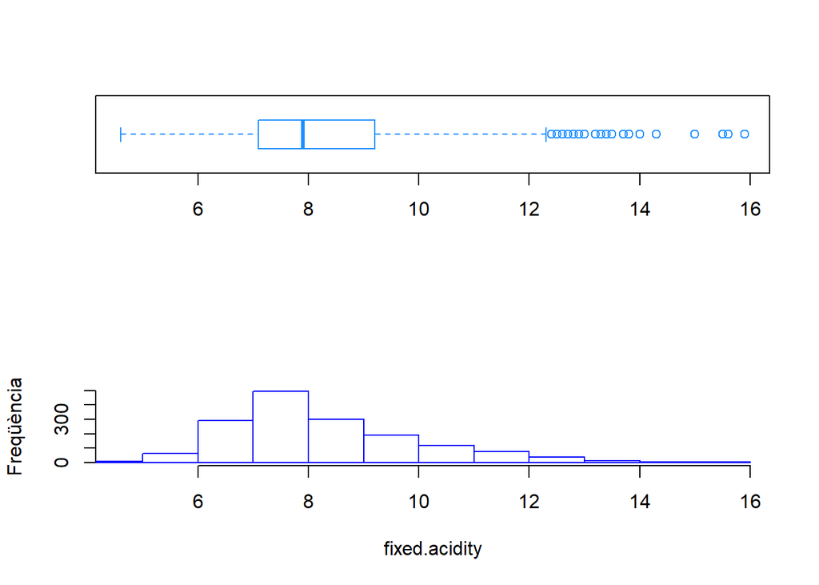

```
## Valors atípics:
##    12.8 12.8 15 15 12.5 13.3 13.4 12.4 12.5 13.8 13.5 12.6 12.5 12.8 12.8 14 13.7 13.7 12.7 12.5 12.8 12.6 15.6 12.5 13 12.5 13.3 12.4 12.5 12.9 14.3 12.4 15.5 15.5 15.6 13 12.7 13 12.7 12.4 12.7 13.2 13.2 13.2 15.9 13.3 12.9 12.6 12.6
## Valors del boxplot:
## 1) Bigoti inf.: 4.6
## 2) Q1(25%)    : 7.1
## 3) Mediana    : 7.9
## 4) Q3(75%)    : 9.2
## 5) Bigoti Sup.: 12.3
```

```r
bxplot_hist(n1$fixed.acidity,'fixed.acidity')
```

```r
cat("Vi blanc")
```

```
## Vi blanc
```

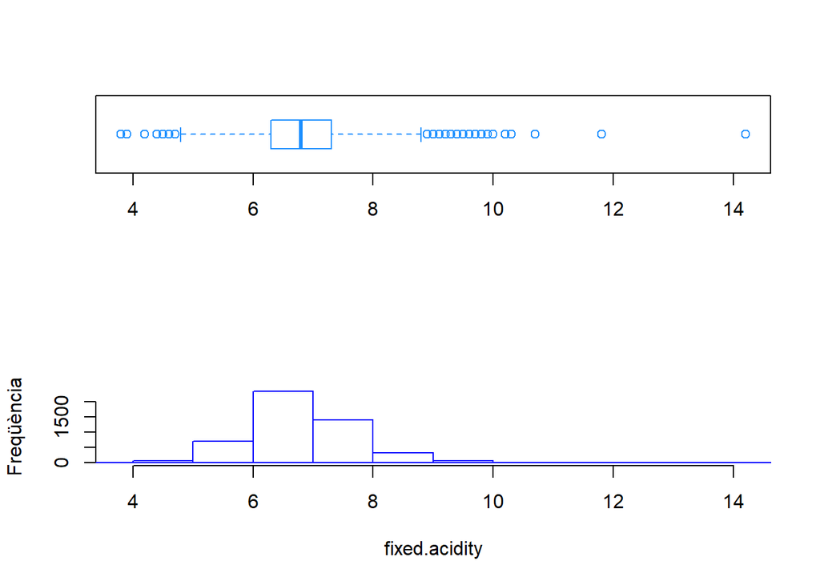

```
## Valors atípics:
##    9.8 9.8 10.2 9.1 10 9.2 9.2 9 9.1 9.2 10.3 9.4 9.2 9.8 9.6 9.2 9 9.3 9.2 9.1 8.9 9.8 8.9 9.2 9.7 9.4 10.3 9.6 9 9.7 9.2 9.4 9.6 9.2 9 9.2 10.7 10.7 9 9.2 9.8 9.2 14.2 8.9 8.9 9.1 9.1 9.8 9 9.3 8.9 9 9 8.9 9 9.3 9.2 9.6 9.4 9.4 10 8.9 8.9 10 9.2 9.2 9.2 9.9 9.5 9 9 8.9 9.5 11.8 9.4 9.1 9.8 9.9 …
## Valors del boxplot:
## 1) Bigoti inf.: 4.8
## 2) Q1(25%)    : 6.3
## 3) Mediana    : 6.8
## 4) Q3(75%)    : 7.3
## 5) Bigoti Sup.: 8.8
```

```r
bxplot_hist(n2$fixed.acidity,'fixed.acidity')
```

```r
cat("Vinho verde sense diferenciar color")
```

```
## Vinho verde sense diferenciar color
```

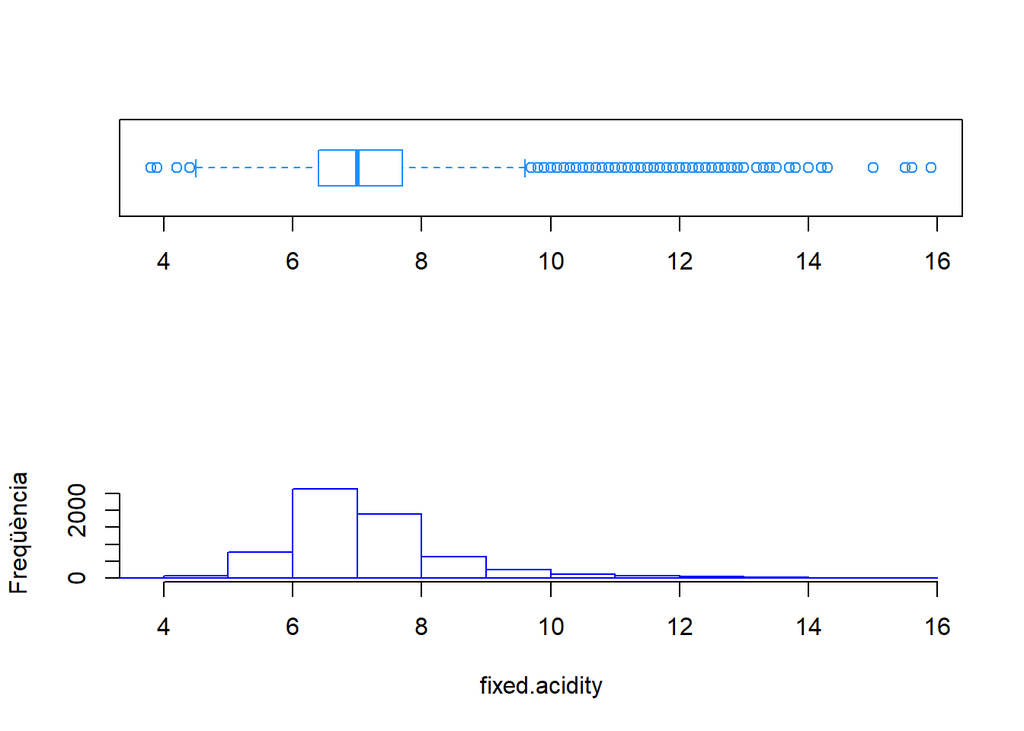

```
## Valors atípics:
##    11.2 10.2 9.7 10.1 11.5 12.8 12.8 11 9.7 11.6 12 15 15 10.8 11.1 10 12.5 11.8 11.5 11.5 10.9 11.5 10.3 11.4 9.9 9.9 12 11.6 11 10.4 13.3 10.8 10.6 11.1 10.3 10.3 10.3 10.3 9.8 9.8 10.3 10 10 11.6 10.3 13.4 10.7 10.2 10.2 11.9 12.4 12.5 12.2 10.6 10.9 10.9 11.9 13.8 10.7 13.5 11.5 10.5 11.9 12.…
## Valors del boxplot:
## 1) Bigoti inf.: 4.5
## 2) Q1(25%)    : 6.4
## 3) Mediana    : 7
## 4) Q3(75%)    : 7.7
## 5) Bigoti Sup.: 9.6
```

```r
bxplot_hist(d$fixed.acidity,'fixed.acidity')
```

No tenim constància de que les dades tinguin errors de captura. Els valors poden ser correctes. Els llindars per els valors extrems serien:

```r
# Cas Vi negre
# Llindar inferior per els valors atípics de 'fixed.acidity'.
cat("Vi negre\nLlindar inferior:",mean(n1$fixed.acidity)-3*sd(n1$fixed.acidity))
```

```
## Vi negre
## Llindar inferior: 3.096348
```

```r
# Llindar superior per el valors atípics de 'fixed.acidity'.
cat("Vi negre\nLlindar superior:",mean(n1$fixed.acidity)+3*sd(n1$fixed.acidity))
```

```
## Vi negre
## Llindar superior: 13.54293
```

```r
# Cas Vi blanc
# Llindar inferior per els valors atípics de 'fixed.acidity'.
cat("Vi blanc\nLlindar inferior:",mean(n2$fixed.acidity)-3*sd(n2$fixed.acidity))
```

```
## Vi blanc
## Llindar inferior: 4.323183
```

```r
# Llindar superior per el valors atípics de 'fixed.acidity'.
cat("Vi negre\nLlindar superior:",mean(n2$fixed.acidity)+3*sd(n2$fixed.acidity))
```

```
## Vi negre
## Llindar superior: 9.386392
```

En aquest cas no modifiquem els valors extrems detectats per els camp ’fixed.acidity.

Atribut: **volatile.acidity**

```r
# Valors extrems de 'volatile.acidity'
cat("Vi negre")
```

```
## Vi negre
```

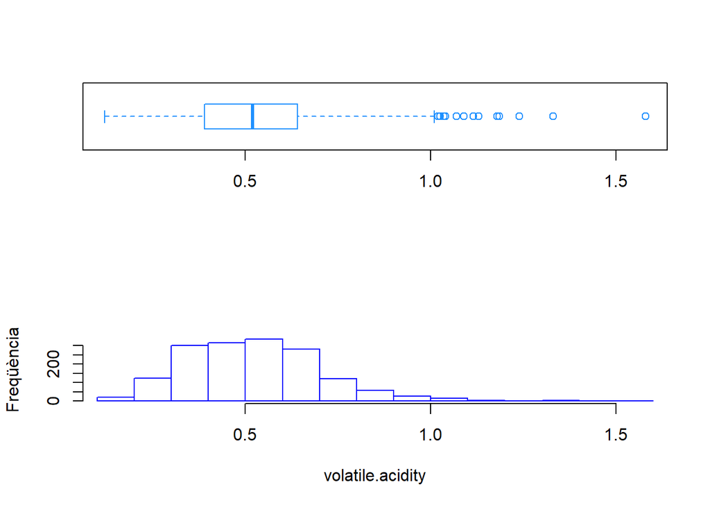

```
## Valors atípics:
##    1.13 1.02 1.07 1.33 1.33 1.04 1.09 1.04 1.24 1.185 1.02 1.035 1.025 1.115 1.02 1.02 1.58 1.18 1.04
## Valors del boxplot:
## 1) Bigoti inf.: 0.12
## 2) Q1(25%)    : 0.39
## 3) Mediana    : 0.52
## 4) Q3(75%)    : 0.64
## 5) Bigoti Sup.: 1.01
```

```r
bxplot_hist(n1$volatile.acidity,'volatile.acidity')
```

```r
cat("Vi blanc")
```

```
## Vi blanc
```

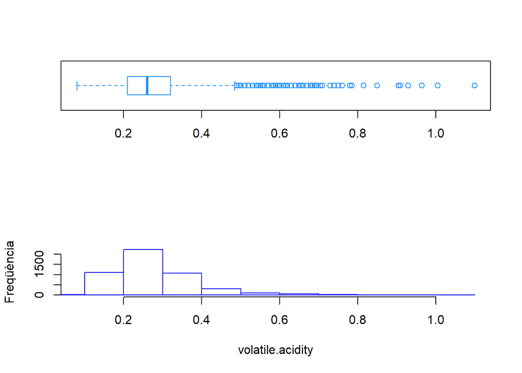

```
## Valors atípics:
##    0.66 0.66 0.67 0.54 0.595 0.67 0.53 0.54 0.57 0.685 0.495 0.64 0.52 0.58 0.585 0.59 0.6 0.58 0.59 0.55 0.905 0.55 0.49 0.55 0.52 0.6 0.55 0.51 0.62 0.51 0.56 0.57 0.67 0.5 0.56 0.56 0.655 0.595 0.705 0.52 0.55 0.6 0.64 0.68 0.49 0.51 0.55 0.52 0.5 0.55 0.6 0.61 0.61 0.61 0.66 0.57 0.5 0.5 0.59…
## Valors del boxplot:
## 1) Bigoti inf.: 0.08
## 2) Q1(25%)    : 0.21
## 3) Mediana    : 0.26
## 4) Q3(75%)    : 0.32
## 5) Bigoti Sup.: 0.485
```

```r
bxplot_hist(n2$volatile.acidity,'volatile.acidity')
```

```r
# Cas Vi negre
# Llindar inferior per els valors atípics de 'volatile.acidity'.
cat("Vi negre\nLlindar inferior:",mean(n1$volatile.acidity)-3*sd(n1$volatile.acidity))
```

```
## Vi negre
## Llindar inferior: -0.0093586
```

```r
# Llindar superior per el valors atípics de 'volatile.acidity'.
cat("Vi negre\nLlindar superior:",mean(n1$volatile.acidity)+3*sd(n1$volatile.acidity))
```

```
## Vi negre
## Llindar superior: 1.065
```

```r
# Cas Vi blanc
# Llindar inferior per els valors atípics de 'volatile.acidity'.
cat("Vi blanc\nLlindar inferior:",mean(n2$volatile.acidity)-3*sd(n2$volatile.acidity))
```

```
## Vi blanc
## Llindar inferior: -0.02414253
```

```r
# Llindar superior per el valors atípics de 'volatile.acidity'.
cat("Vi negre\nLlindar superior:",mean(n2$volatile.acidity)+3*sd(n2$volatile.acidity))
```

```
## Vi negre
## Llindar superior: 0.5806248
```

La variació d’aquests valors no afecta sensiblement als paràmetres representatius de la seva distribució, però si ho necessitem més endavant podriem substituïr el seu valor per el de la mediana 0.52, com a valor representatiu de la seva distribució. Mètodes més robustos com la imputació de dades amb kNN, package R “DMwR” mitjançant la función <b<knnImputation(), o el package R “VIM” usant la funció <b<kNN().

Atribut: **citric.acid**

```r
# Valors extrems de 'citric.acid'
cat("Vi negre")
```

```
## Vi negre
```

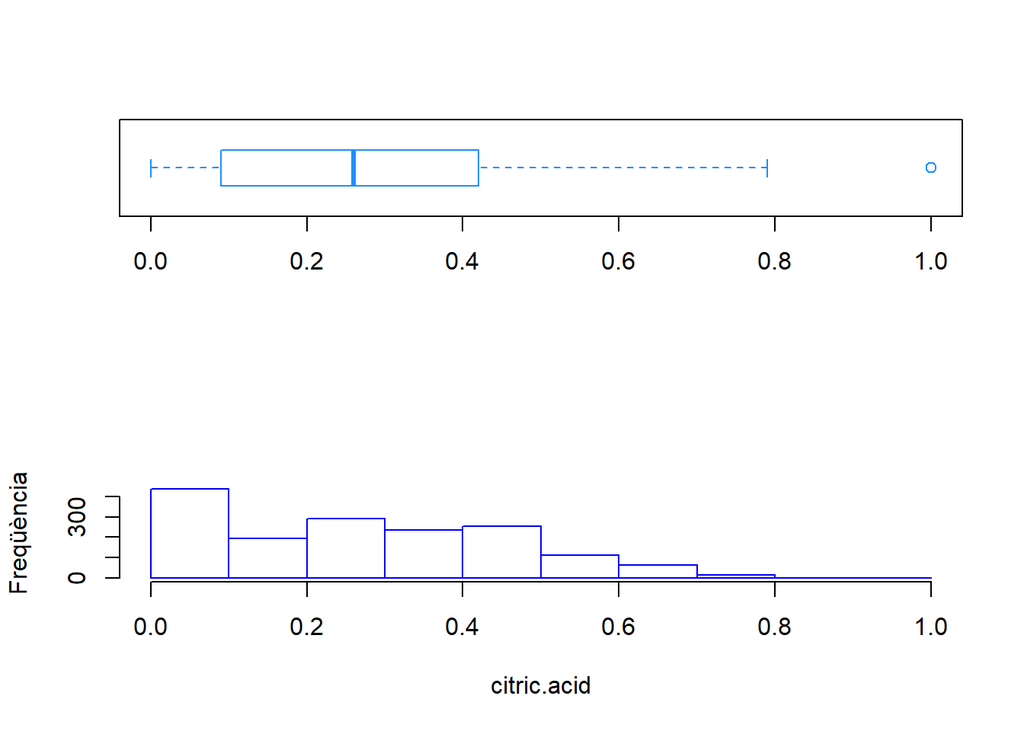

```
## Valors atípics:
##    1
## Valors del boxplot:
## 1) Bigoti inf.: 0
## 2) Q1(25%)    : 0.09
## 3) Mediana    : 0.26
## 4) Q3(75%)    : 0.42
## 5) Bigoti Sup.: 0.79
```

```r
bxplot_hist(n1$citric.acid,'citric.acid')
```

```r
cat("Vi blanc")
```

```
## Vi blanc
```

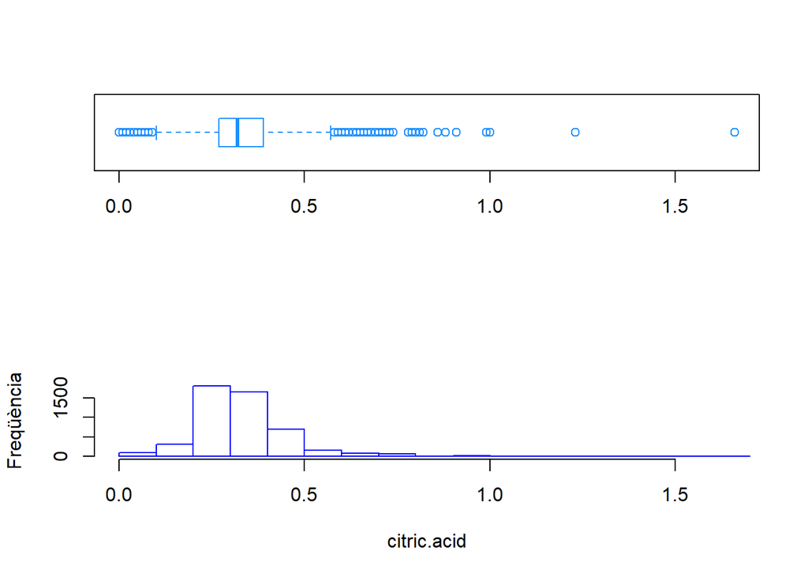

```
## Valors atípics:
##    0.62 0.04 0.59 0.07 0.03 0.61 0.62 0.63 0.61 0.62 0.63 0.66 0.66 0 0.04 0.67 0.67 0.04 0.04 0.07 0.88 0.08 0.59 0.07 0.07 0.07 0.07 0.58 0.7 0 0 0.6 0.07 0.09 0.04 0.62 0.58 0.62 0.7 0.62 0.62 0.58 0.02 0.65 0.65 0.71 0.66 0.66 0.07 0.06 0.07 0.06 0.68 0.68 0.68 0.68 0.06 0.72 0.69 0.58 0.7 1.…
## Valors del boxplot:
## 1) Bigoti inf.: 0.1
## 2) Q1(25%)    : 0.27
## 3) Mediana    : 0.32
## 4) Q3(75%)    : 0.39
## 5) Bigoti Sup.: 0.57
```

```r
bxplot_hist(n2$citric.acid,'citric.acid')
```

```r
# Cas Vi negre
# Llindar inferior per els valors atípics de 'citric.acid'.
cat("Vi negre\nLlindar inferior:",mean(n1$citric.acid)-3*sd(n1$citric.acid))
```

```
## Vi negre
## Llindar inferior: -0.3134278
```

```r
# Llindar superior per el valors atípics de 'citric.acid'.
cat("Vi negre\nLlindar superior:",mean(n1$citric.acid)+3*sd(n1$citric.acid))
```

```
## Vi negre
## Llindar superior: 0.855379
```

```r
# Cas Vi blanc
# Llindar inferior per els valors atípics de 'citric.acid'.
cat("Vi blanc\nLlindar inferior:",mean(n2$citric.acid)-3*sd(n2$citric.acid))
```

```
## Vi blanc
## Llindar inferior: -0.02886791
```

```r
# Llindar superior per el valors atípics de 'citric.acid'.
cat("Vi negre\nLlindar superior:",mean(n2$citric.acid)+3*sd(n2$citric.acid))
```

```
## Vi negre
## Llindar superior: 0.6972509
```

Atribut: **residual.sugar**

```r
# Valors extrems de 'residual.sugar'
cat("Vi negre")
```

```
## Vi negre
```

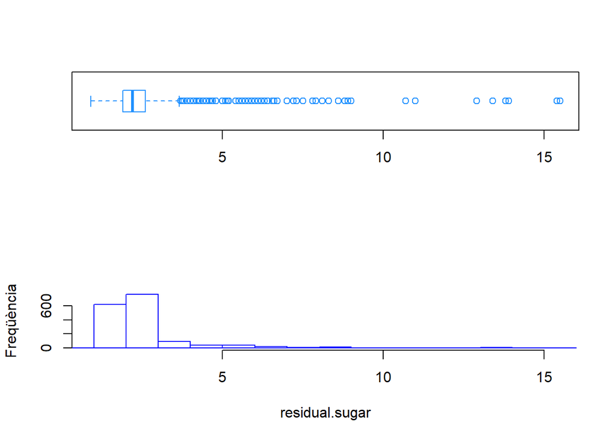

```
## Valors atípics:
##    6.1 6.1 3.8 3.9 4.4 10.7 5.5 5.9 5.9 3.8 5.1 4.65 4.65 5.5 5.5 5.5 5.5 7.3 7.2 3.8 5.6 4 4 4 4 7 4 4 6.4 5.6 5.6 11 11 4.5 4.8 5.8 5.8 3.8 4.4 6.2 4.2 7.9 7.9 3.7 4.5 6.7 6.6 3.7 5.2 15.5 4.1 8.3 6.55 6.55 4.6 6.1 4.3 5.8 5.15 6.3 4.2 4.2 4.6 4.2 4.6 4.3 4.3 7.9 4.6 5.1 5.6 5.6 6 8.6 7.5 4.4 4…
## Valors del boxplot:
## 1) Bigoti inf.: 0.9
## 2) Q1(25%)    : 1.9
## 3) Mediana    : 2.2
## 4) Q3(75%)    : 2.6
## 5) Bigoti Sup.: 3.65
```

```r
bxplot_hist(n1$residual.sugar,'residual.sugar')
```

```r
cat("Vi blanc")
```

```
## Vi blanc
```

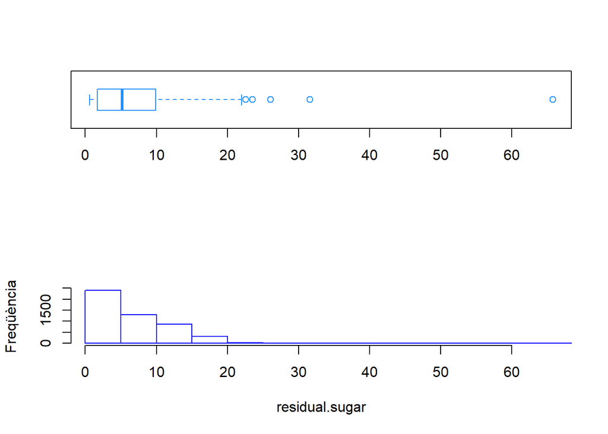

```
## Valors atípics:
##    23.5 31.6 31.6 65.8 26.05 26.05 22.6
## Valors del boxplot:
## 1) Bigoti inf.: 0.6
## 2) Q1(25%)    : 1.7
## 3) Mediana    : 5.2
## 4) Q3(75%)    : 9.9
## 5) Bigoti Sup.: 22
```

```r
bxplot_hist(n2$residual.sugar,'residual.sugar')
```

```r
# Cas Vi negre
# Llindar inferior per els valors atípics de 'residual.sugar'.
cat("Vi negre\nLlindar inferior:",mean(n1$residual.sugar)-3*sd(n1$residual.sugar))
```

```
## Vi negre
## Llindar inferior: -1.690979
```

```r
# Llindar superior per el valors atípics de 'residual.sugar'.
cat("Vi negre\nLlindar superior:",mean(n1$residual.sugar)+3*sd(n1$residual.sugar))
```

```
## Vi negre
## Llindar superior: 6.76859
```

```r
# Cas Vi blanc
# Llindar inferior per els valors atípics de 'residual.sugar'.
cat("Vi blanc\nLlindar inferior:",mean(n2$residual.sugar)-3*sd(n2$residual.sugar))
```

```
## Vi blanc
## Llindar inferior: -8.824758
```

```r
# Llindar superior per el valors atípics de 'residual.sugar'.
cat("Vi negre\nLlindar superior:",mean(n2$residual.sugar)+3*sd(n2$residual.sugar))
```

```
## Vi negre
## Llindar superior: 21.60759
```

En aquest cas hem trobat valors atípics molt extrems.  
Si tenim en compte l’escala de dolçor dels vins:

- 0-9 g/l Sucre residual (SR): Sec
- 9-18 g/l: No Sec
- 18-50 g/l: Mig sec-Semi dolç
- 50-120 g/l: mig-dolç
- 120 g/l Dolç-Molt dolç

Deduïm que el ‘Vinho verde’ és un vi que pot ser ‘Sec’, ‘No sec’, ‘Mig sec’ però no ‘Semi dolç’, ‘Mig dolç’ o ‘Dolç-Molt dolç’. Per tant establim un llindar lògic de residual.sugar=18. Decidim eliminar aquests valors atípics que hem trobat en el vi blanc, per considerar que són poques instàncies, que representen un 2% del total d’instàncies de vi blanc. Hem observat que la majoria de valors eliminats tenia un valor de qualitat 5,6,7,8 i això implicaria que un valor incorrecte del ‘sucre residual’ no fos una característica que ens ajudes a discriminar la qualitat del vi.

```r
# Eliminem les instàncies amb valors atípics incorrectes.
n2<-n2[n2$residual.sugar<=18,]
```

Atribut: **chlorides**

```r
# Valors extrems de 'chlorides'
cat("Vi negre")
```

```
## Vi negre
```

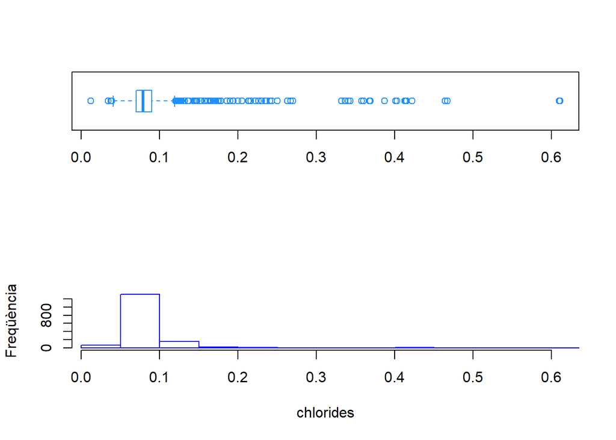

```
## Valors atípics:
##    0.176 0.17 0.368 0.341 0.172 0.332 0.464 0.401 0.467 0.122 0.178 0.146 0.236 0.61 0.36 0.27 0.039 0.337 0.263 0.611 0.358 0.343 0.186 0.213 0.214 0.121 0.122 0.122 0.128 0.12 0.159 0.124 0.122 0.122 0.174 0.121 0.127 0.413 0.152 0.152 0.125 0.122 0.2 0.171 0.226 0.226 0.25 0.148 0.122 0.124 0.…
## Valors del boxplot:
## 1) Bigoti inf.: 0.041
## 2) Q1(25%)    : 0.07
## 3) Mediana    : 0.079
## 4) Q3(75%)    : 0.09
## 5) Bigoti Sup.: 0.119
```

```r
bxplot_hist(n1$chlorides,'chlorides')
```

```r
cat("Vi blanc")
```

```
## Vi blanc
```

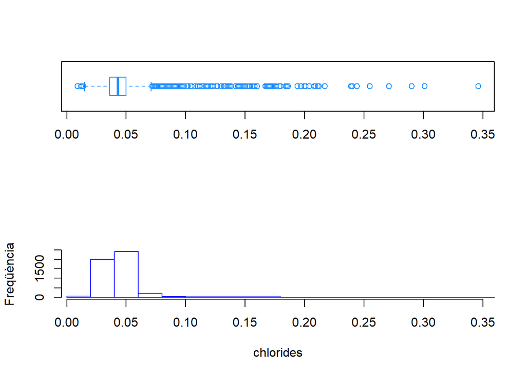

```
## Valors atípics:
##    0.074 0.08 0.172 0.173 0.147 0.092 0.082 0.092 0.2 0.197 0.197 0.074 0.132 0.089 0.108 0.081 0.073 0.346 0.09 0.114 0.186 0.18 0.084 0.083 0.096 0.094 0.24 0.29 0.185 0.11 0.078 0.13 0.135 0.115 0.072 0.17 0.08 0.119 0.126 0.15 0.152 0.088 0.244 0.137 0.093 0.077 0.079 0.073 0.072 0.076 0.201 …
## Valors del boxplot:
## 1) Bigoti inf.: 0.015
## 2) Q1(25%)    : 0.036
## 3) Mediana    : 0.043
## 4) Q3(75%)    : 0.05
## 5) Bigoti Sup.: 0.071
```

```r
bxplot_hist(n2$chlorides,'chlorides')
```

```r
# Cas Vi negre
# Llindar inferior per els valors atípics de 'chlorides'.
cat("Vi negre\nLlindar inferior:",mean(n1$chlorides)-3*sd(n1$chlorides))
```

```
## Vi negre
## Llindar inferior: -0.05372936
```

```r
# Llindar superior per el valors atípics de 'chlorides'.
cat("Vi negre\nLlindar superior:",mean(n1$chlorides)+3*sd(n1$chlorides))
```

```
## Vi negre
## Llindar superior: 0.2286624
```

```r
# Cas Vi blanc
# Llindar inferior per els valors atípics de 'chlorides'.
cat("Vi blanc\nLlindar inferior:",mean(n2$chlorides)-3*sd(n2$chlorides))
```

```
## Vi blanc
## Llindar inferior: -0.02010456
```

```r
# Llindar superior per el valors atípics de 'chlorides'.
cat("Vi negre\nLlindar superior:",mean(n2$chlorides)+3*sd(n2$chlorides))
```

```
## Vi negre
## Llindar superior: 0.1114649
```

Atribut: **free.sulfur.dioxide**

```r
# Valors extrems de 'free.sulfur.dioxide'
cat("Vi negre")
```

```
## Vi negre
```

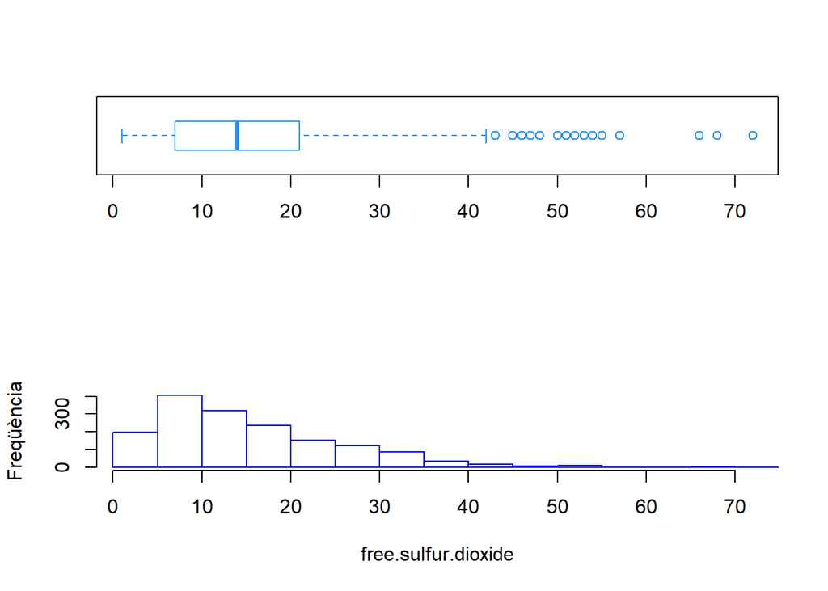

```
## Valors atípics:
##    52 51 50 68 68 43 47 54 46 45 53 52 51 45 57 50 45 48 43 48 72 43 51 51 52 55 55 48 48 66
## Valors del boxplot:
## 1) Bigoti inf.: 1
## 2) Q1(25%)    : 7
## 3) Mediana    : 14
## 4) Q3(75%)    : 21
## 5) Bigoti Sup.: 42
```

```r
bxplot_hist(n1$free.sulfur.dioxide,'free.sulfur.dioxide')
```

```r
cat("Vi blanc")
```

```
## Vi blanc
```

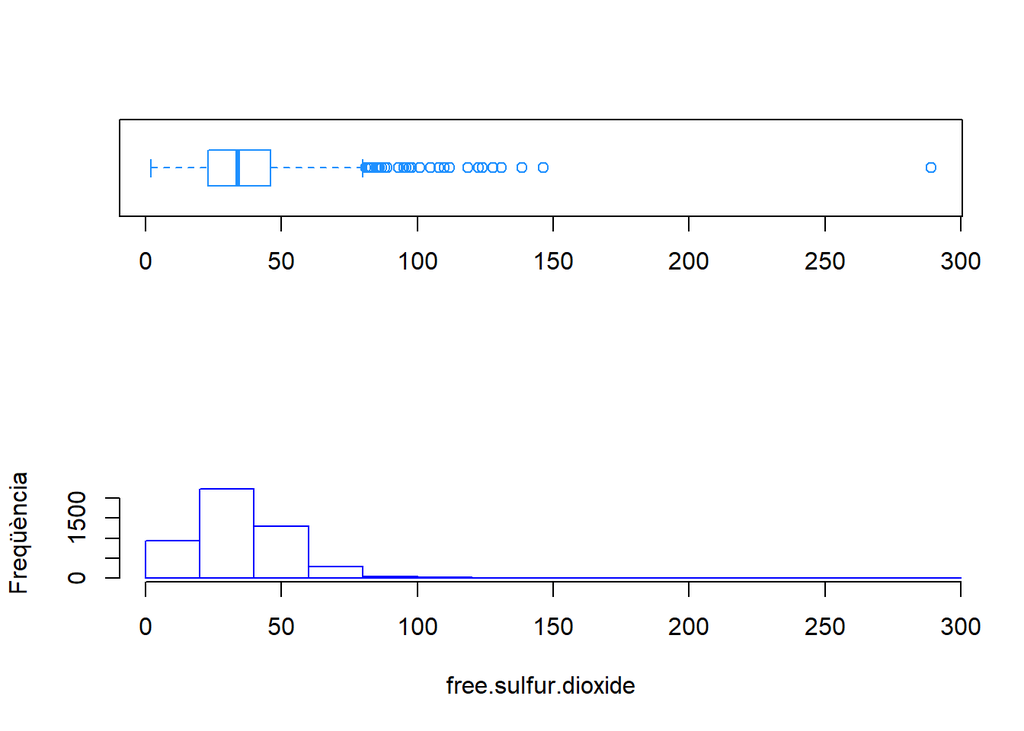

```
## Valors atípics:
##    81 82 131 82.5 87 87 83 122.5 83 81 88 82 118.5 81 96 83 83 146.5 128 110 85 89 86 86 96 96 93 85 81 138.5 95 124 87 87 105 105 101 101 108 108 98 98 112 108 98 81 81 81 289 97
## Valors del boxplot:
## 1) Bigoti inf.: 2
## 2) Q1(25%)    : 23
## 3) Mediana    : 34
## 4) Q3(75%)    : 46
## 5) Bigoti Sup.: 80
```

```r
bxplot_hist(n2$free.sulfur.dioxide,'free.sulfur.dioxide')
```

```r
# Cas Vi negre
# Llindar inferior per els valors atípics de 'free.sulfur.dioxide'.
cat("Vi negre\nLlindar inferior:",mean(n1$free.sulfur.dioxide)-3*sd(n1$free.sulfur.dioxide))
```

```
## Vi negre
## Llindar inferior: -15.50555
```

```r
# Llindar superior per el valors atípics de 'free.sulfur.dioxide'.
cat("Vi negre\nLlindar superior:",mean(n1$free.sulfur.dioxide)+3*sd(n1$free.sulfur.dioxide))
```

```
## Vi negre
## Llindar superior: 47.25539
```

```r
# Cas Vi blanc
# Llindar inferior per els valors atípics de 'free.sulfur.dioxide'.
cat("Vi blanc\nLlindar inferior:",mean(n2$free.sulfur.dioxide)-3*sd(n2$free.sulfur.dioxide))
```

```
## Vi blanc
## Llindar inferior: -15.96384
```

```r
# Llindar superior per el valors atípics de 'free.sulfur.dioxide'.
cat("Vi negre\nLlindar superior:",mean(n2$free.sulfur.dioxide)+3*sd(n2$free.sulfur.dioxide))
```

```
## Vi negre
## Llindar superior: 86.41826
```

En el cas del dioxid de sofre, sabem que la normativa admet fins valors de <b<300 g/l tot i que a Europa no es solen observar valors superiors a **50 g/l**. Observem que els valors atípics tenen valors alts sobretot en el vi blanc, però com no sobrepasen la normativa i poden ser correctes i els valors estan representats en totes les categories de qualitat del vi, decidim no modificar les dades. L’ús del diòxid de sofre en el vi és com a conservant i volem mantenir l’efecte de que és més usat en el vi blanc.

Atribut: **total.sulfur.dioxide**

```r
# Valors extrems de 'total.sulfur.dioxide'
cat("Vi negre")
```

```
## Vi negre
```

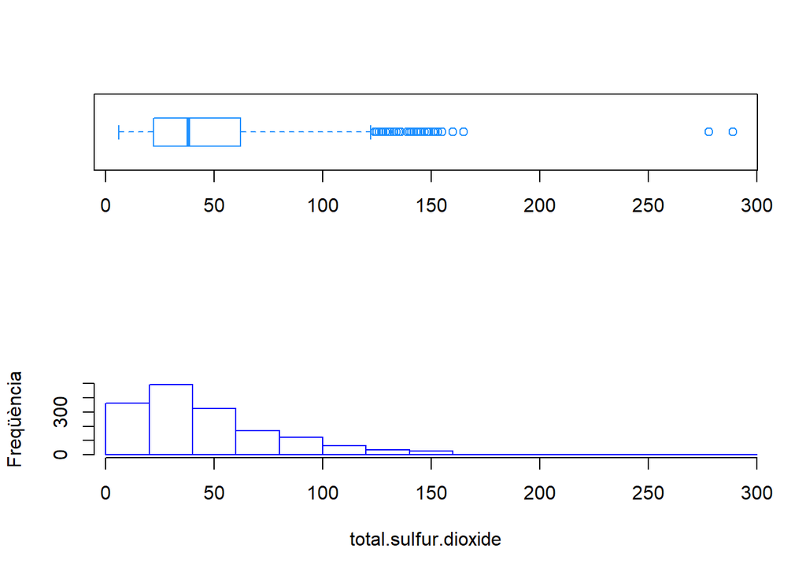

```
## Valors atípics:
##    145 148 136 125 140 136 133 153 134 141 129 128 129 128 143 144 127 126 145 144 135 165 124 124 134 124 129 151 133 142 149 147 145 148 155 151 152 125 127 139 143 144 130 278 289 135 160 141 141 133 147 147 131 131 131
## Valors del boxplot:
## 1) Bigoti inf.: 6
## 2) Q1(25%)    : 22
## 3) Mediana    : 38
## 4) Q3(75%)    : 62
## 5) Bigoti Sup.: 122
```

```r
bxplot_hist(n1$total.sulfur.dioxide,'total.sulfur.dioxide')
```

```r
cat("Vi blanc")
```

```
## Vi blanc
```

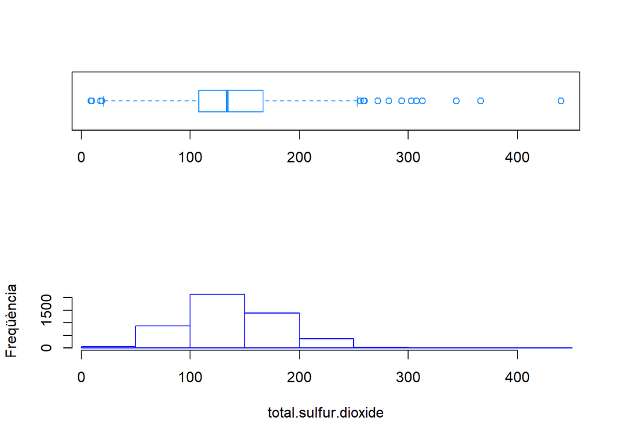

```
## Valors atípics:
##    272 313 260 19 366.5 307.5 256 256 344 282 303 272 18 18 294 9 10 259 440
## Valors del boxplot:
## 1) Bigoti inf.: 21
## 2) Q1(25%)    : 108
## 3) Mediana    : 134
## 4) Q3(75%)    : 167
## 5) Bigoti Sup.: 253
```

```r
bxplot_hist(n2$total.sulfur.dioxide,'total.sulfur.dioxide')
```

```r
# Cas Vi negre
# Llindar inferior per els valors atípics de 'total.sulfur.dioxide'.
cat("Vi negre\nLlindar inferior:",mean(n1$total.sulfur.dioxide)-3*sd(n1$total.sulfur.dioxide))
```

```
## Vi negre
## Llindar inferior: -52.21818
```

```r
# Llindar superior per el valors atípics de 'total.sulfur.dioxide'.
cat("Vi negre\nLlindar superior:",mean(n1$total.sulfur.dioxide)+3*sd(n1$total.sulfur.dioxide))
```

```
## Vi negre
## Llindar superior: 145.1538
```

```r
# Cas Vi blanc
# Llindar inferior per els valors atípics de 'total.sulfur.dioxide'.
cat("Vi blanc\nLlindar inferior:",mean(n2$total.sulfur.dioxide)-3*sd(n2$total.sulfur.dioxide))
```

```
## Vi blanc
## Llindar inferior: 10.61887
```

```r
# Llindar superior per el valors atípics de 'total.sulfur.dioxide'.
cat("Vi negre\nLlindar superior:",mean(n2$total.sulfur.dioxide)+3*sd(n2$total.sulfur.dioxide))
```

```
## Vi negre
## Llindar superior: 265.1633
```

En aquest obtenim valors força alts però sabem que aquest camp s’obté de la suma del diòxid de sofre lliure i el fixat, per tant preveiem que aquest atribut no l’utilitzem en els anàlisis, per ser combinació lineal de ‘free.sulfur.dioxide’.

Atribut: **density**

```r
# Valors extrems de 'density'
cat("Vi negre")
```

```
## Vi negre
```

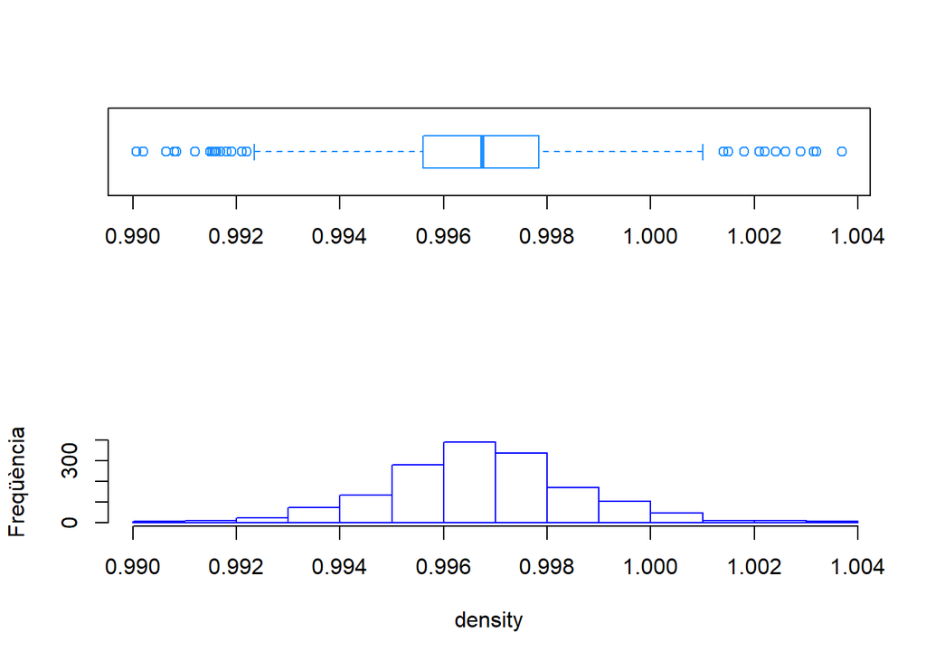

```
## Valors atípics:
##    0.9916 0.9916 1.0014 1.0015 1.0015 1.0018 0.9912 1.0022 1.0022 1.0014 1.0014 1.0014 1.0014 1.0032 1.0026 1.0014 1.00315 1.00315 1.00315 1.0021 1.0021 0.9917 0.9922 1.0026 0.9921 0.99154 0.99064 0.99064 1.00289 0.99162 0.99007 0.99007 0.9902 0.9922 0.9915 0.99157 0.9908 0.99084 0.99191 1.00369 …
## Valors del boxplot:
## 1) Bigoti inf.: 0.99235
## 2) Q1(25%)    : 0.9956
## 3) Mediana    : 0.99675
## 4) Q3(75%)    : 0.997835
## 5) Bigoti Sup.: 1.001
```

```r
bxplot_hist(n1$density,'density')
```

```r
cat("Vi blanc")
```

```
## Vi blanc
```

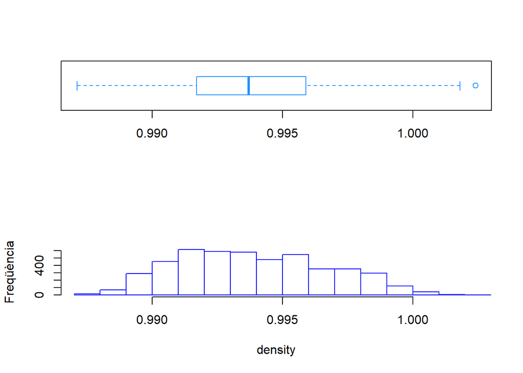

```
## Valors atípics:
##    1.00241
## Valors del boxplot:
## 1) Bigoti inf.: 0.98711
## 2) Q1(25%)    : 0.9917
## 3) Mediana    : 0.9937
## 4) Q3(75%)    : 0.9959
## 5) Bigoti Sup.: 1.00182
```

```r
bxplot_hist(n2$density,'density')
```

```r
# Cas Vi negre
# Llindar inferior per els valors atípics de 'density'.
cat("Vi negre\nLlindar inferior:",mean(n1$density)-3*sd(n1$density))
```

```
## Vi negre
## Llindar inferior: 0.9910847
```

```r
# Llindar superior per el valors atípics de 'density'.
cat("Vi negre\nLlindar superior:",mean(n1$density)+3*sd(n1$density))
```

```
## Vi negre
## Llindar superior: 1.002409
```

```r
# Cas Vi blanc
# Llindar inferior per els valors atípics de 'density'.
cat("Vi blanc\nLlindar inferior:",mean(n2$density)-3*sd(n2$density))
```

```
## Vi blanc
## Llindar inferior: 0.985438
```

```r
# Llindar superior per el valors atípics de 'density'.
cat("Vi negre\nLlindar superior:",mean(n2$density)+3*sd(n2$density))
```

```
## Vi negre
## Llindar superior: 1.002394
```

En el cas de la ‘densitat’, obtenim valors atípics, però no estem segurs de que siguin incorrectes. Les distribucions queden ben descrites per els paràmetres estadístics com la mediana. No volem perdre informació del dataset i per tant no eliminem ni modifiquem cap valor.

Atribut: **pH**

```r
# Valors extrems de 'pH'
cat("Vi negre")
```

```
## Vi negre
```

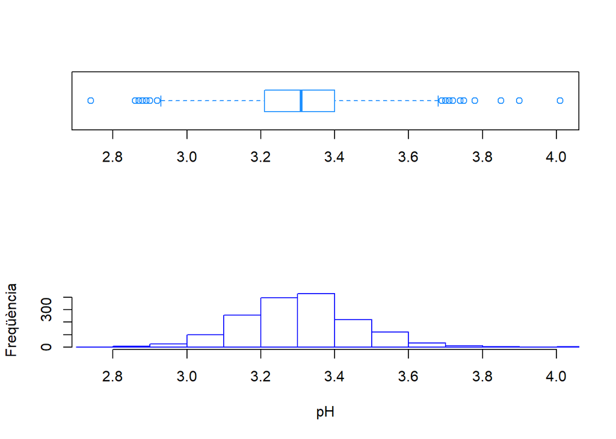

```
## Valors atípics:
##    3.9 3.75 3.85 2.74 3.69 3.69 2.88 2.86 3.74 2.92 2.92 2.92 3.72 2.87 2.89 2.89 2.92 3.9 3.71 3.69 3.69 3.71 3.71 2.89 2.89 3.78 3.7 3.78 4.01 2.9 4.01 3.71 2.88 3.72 3.72
## Valors del boxplot:
## 1) Bigoti inf.: 2.93
## 2) Q1(25%)    : 3.21
## 3) Mediana    : 3.31
## 4) Q3(75%)    : 3.4
## 5) Bigoti Sup.: 3.68
```

```r
bxplot_hist(n1$pH,'pH')
```

```r
cat("Vi blanc")
```

```
## Vi blanc
```

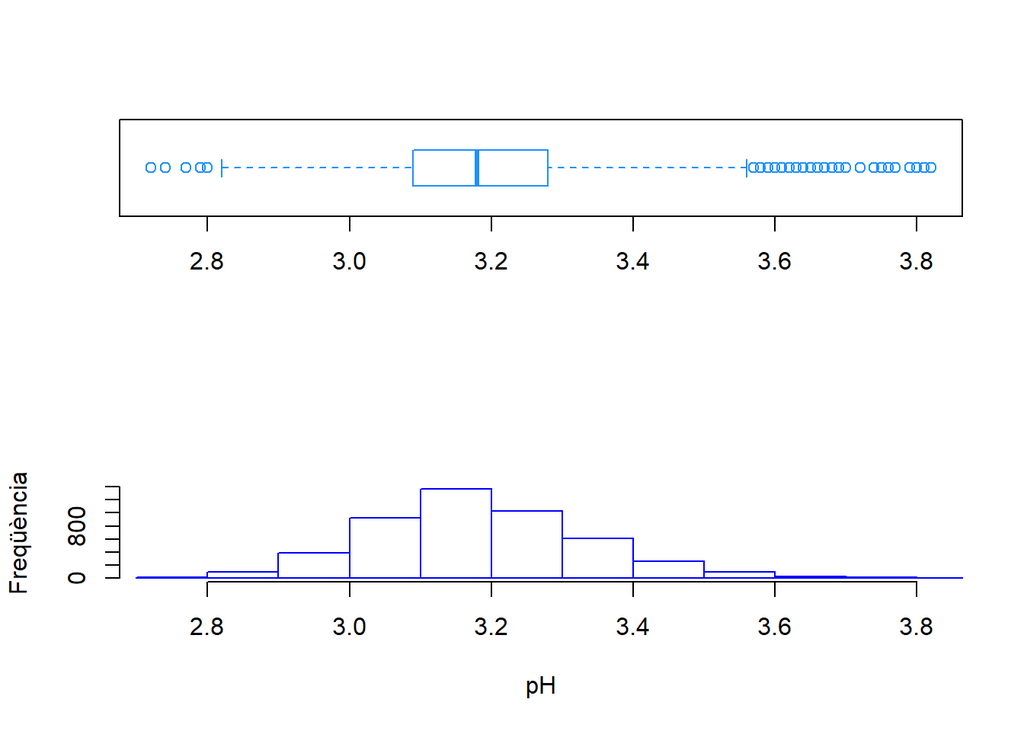

```
## Valors atípics:
##    3.69 3.63 3.72 3.61 3.64 3.64 3.72 3.72 3.58 3.58 3.66 3.59 2.74 3.82 3.81 3.65 3.65 3.59 3.77 3.62 3.63 3.58 3.58 3.65 3.74 2.8 3.6 3.6 2.72 3.6 2.79 2.79 3.57 3.8 3.6 3.6 3.68 3.63 3.63 2.77 3.63 3.6 3.6 3.61 3.61 3.59 3.79 3.59 3.68 3.59 3.66 3.7 3.74 3.8 3.57 3.57 3.57 3.65 3.58 2.8 3.77 3…
## Valors del boxplot:
## 1) Bigoti inf.: 2.82
## 2) Q1(25%)    : 3.09
## 3) Mediana    : 3.18
## 4) Q3(75%)    : 3.28
## 5) Bigoti Sup.: 3.56
```

```r
bxplot_hist(n2$pH,'pH')
```

```r
# Cas Vi negre
# Llindar inferior per els valors atípics de 'pH'.
cat("Vi negre\nLlindar inferior:",mean(n1$pH)-3*sd(n1$pH))
```

```
## Vi negre
## Llindar inferior: 2.847954
```

```r
# Llindar superior per el valors atípics de 'pH'.
cat("Vi negre\nLlindar superior:",mean(n1$pH)+3*sd(n1$pH))
```

```
## Vi negre
## Llindar superior: 3.774273
```

```r
# Cas Vi blanc
# Llindar inferior per els valors atípics de 'pH'.
cat("Vi blanc\nLlindar inferior:",mean(n2$pH)-3*sd(n2$pH))
```

```
## Vi blanc
## Llindar inferior: 2.7363
```

```r
# Llindar superior per el valors atípics de 'pH'.
cat("Vi negre\nLlindar superior:",mean(n2$pH)+3*sd(n2$pH))
```

```
## Vi negre
## Llindar superior: 3.642566
```

En el cas del ‘pH’, és igual que el cas anterior, podem mantenir els valors atípics, ja que poden ser valors correctes i no tenim seguretat d’error. En general abans de modificar les dades cal estar segur de que realment és necessari, perque podriem estar eliminant patrons en les dades que per no semblar-nos ‘coherents’ d’entrada són valors que indiquen una variació en una tendència incipient.Sabem que el pH marca la acidesa del vi, per tant és probable que el pH tingui alguna correlació amb els atributs ‘fixed.acidity’ o ‘citric.acid’.

Atribut: **sulphates**

```r
# Valors extrems de 'sulphates'
cat("Vi negre")
```

```
## Vi negre
```

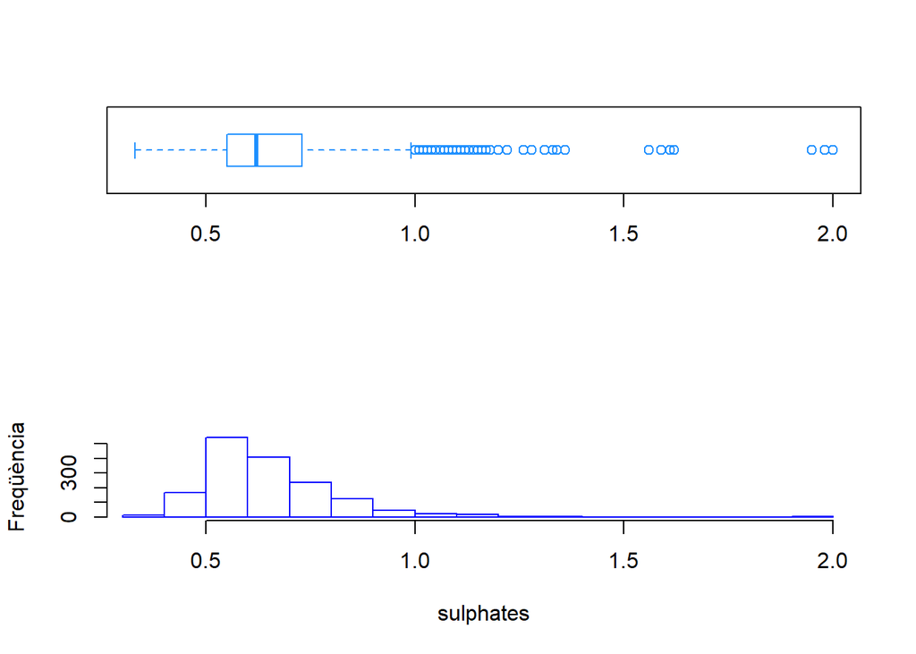

```
## Valors atípics:
##    1.56 1.28 1.08 1.2 1.12 1.28 1.14 1.95 1.22 1.95 1.98 1.31 2 1.08 1.59 1.02 1.03 1.61 1.09 1.26 1.08 1 1.36 1.18 1.13 1.04 1.11 1.13 1.07 1.06 1.06 1.05 1.06 1.04 1.05 1.02 1.14 1.02 1.36 1.36 1.05 1.17 1.62 1.06 1.18 1.07 1.34 1.16 1.1 1.15 1.17 1.17 1.33 1.18 1.17 1.03 1.17 1.1 1.01
## Valors del boxplot:
## 1) Bigoti inf.: 0.33
## 2) Q1(25%)    : 0.55
## 3) Mediana    : 0.62
## 4) Q3(75%)    : 0.73
## 5) Bigoti Sup.: 0.99
```

```r
bxplot_hist(n1$sulphates,'sulphates')
```

```r
cat("Vi blanc")
```

```
## Vi blanc
```

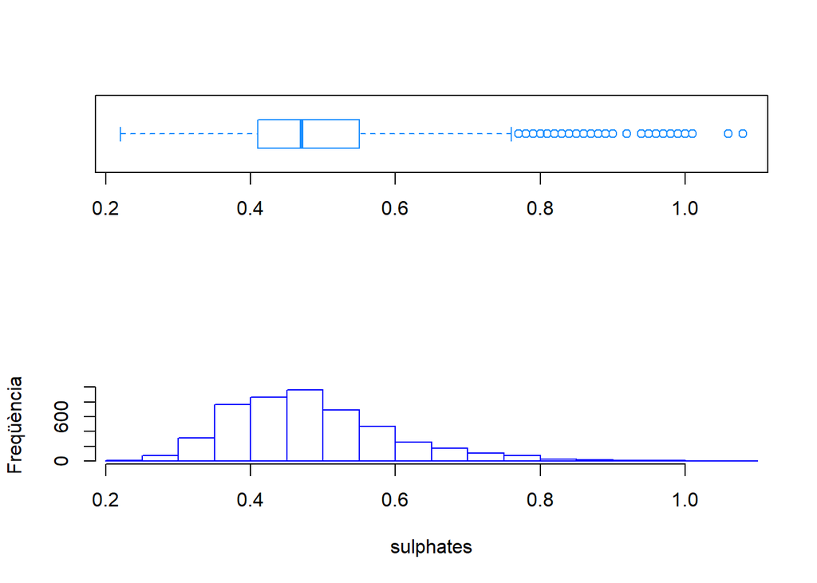

```
## Valors atípics:
##    0.77 0.84 0.77 0.79 0.85 0.78 0.79 0.79 0.79 0.77 0.78 0.85 0.96 0.97 0.82 0.82 0.77 0.95 0.95 0.77 0.95 0.82 0.82 0.9 0.88 0.88 0.79 0.8 0.8 0.78 0.78 0.87 0.86 0.9 0.9 0.78 0.79 0.81 0.81 0.77 0.82 0.79 0.79 0.77 0.82 0.92 0.79 0.79 0.82 0.82 0.82 0.82 0.82 0.79 0.78 0.79 0.77 0.77 0.77 0.98…
## Valors del boxplot:
## 1) Bigoti inf.: 0.22
## 2) Q1(25%)    : 0.41
## 3) Mediana    : 0.47
## 4) Q3(75%)    : 0.55
## 5) Bigoti Sup.: 0.76
```

```r
bxplot_hist(n2$sulphates,'sulphates')
```

```r
# Cas Vi negre
# Llindar inferior per els valors atípics de 'sulphates'.
cat("Vi negre\nLlindar inferior:",mean(n1$sulphates)-3*sd(n1$sulphates))
```

```
## Vi negre
## Llindar inferior: 0.1496279
```

```r
# Llindar superior per el valors atípics de 'sulphates'.
cat("Vi negre\nLlindar superior:",mean(n1$sulphates)+3*sd(n1$sulphates))
```

```
## Vi negre
## Llindar superior: 1.16667
```

```r
# Cas Vi blanc
# Llindar inferior per els valors atípics de 'sulphates'.
cat("Vi blanc\nLlindar inferior:",mean(n2$sulphates)-3*sd(n2$sulphates))
```

```
## Vi blanc
## Llindar inferior: 0.146229
```

```r
# Llindar superior per el valors atípics de 'sulphates'.
cat("Vi negre\nLlindar superior:",mean(n2$sulphates)+3*sd(n2$sulphates))
```

```
## Vi negre
## Llindar superior: 0.8342113
```

Els sulfats de sodi i calci apareixen en l’aigua i per tant el raïm i el vi poden contenir-los. Una alta concentració dels mateixos podria fer que una aigua no fos de qualitat alimentària. Una aigua amb una quantitat de sulfats inferior a 250mg /l es considera en aquest aspecte una aigua de qualitat i amb valors superiors a 400 mg / l insalubre.  
Per tant suposem aquest camp important per determinar la qualitat del vi. Igual que en els dos darrers cassos no trobem valors atípics que no puguin ser correctes, i per tant conservem tots els valors.

Atribut: **alcohol**

```r
# Valors extrems de 'alcohol'
cat("Vi negre")
```

```
## Vi negre
```

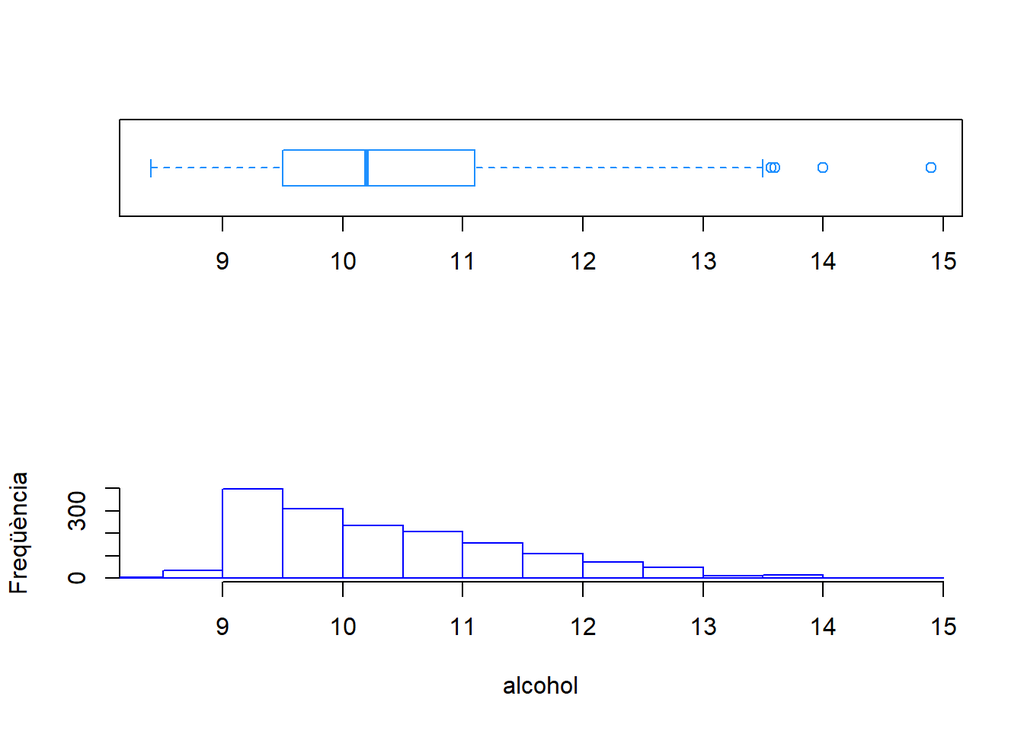

```
## Valors atípics:
##    14 14 14 14 14.9 14 13.6 13.6 13.6 14 14 13.56667 13.6
## Valors del boxplot:
## 1) Bigoti inf.: 8.4
## 2) Q1(25%)    : 9.5
## 3) Mediana    : 10.2
## 4) Q3(75%)    : 11.1
## 5) Bigoti Sup.: 13.5
```

```r
bxplot_hist(n1$alcohol,'alcohol')
```

```r
cat("Vi blanc")
```

```
## Vi blanc
```

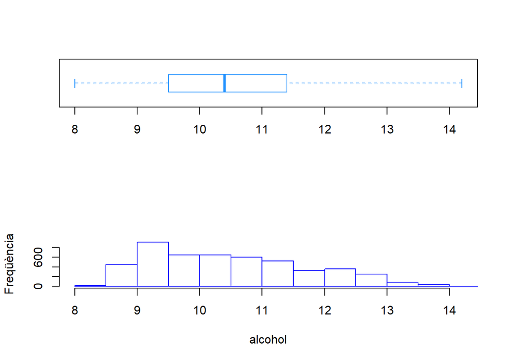

```
## Valors atípics:
##
## Valors del boxplot:
## 1) Bigoti inf.: 8
## 2) Q1(25%)    : 9.5
## 3) Mediana    : 10.4
## 4) Q3(75%)    : 11.4
## 5) Bigoti Sup.: 14.2
```

```r
bxplot_hist(n2$alcohol,'alcohol')
```

```r
# Cas Vi negre
# Llindar inferior per els valors atípics de 'alcohol'.
cat("Vi negre\nLlindar inferior:",mean(n1$alcohol)-3*sd(n1$alcohol))
```

```
## Vi negre
## Llindar inferior: 7.22598
```

```r
# Llindar superior per el valors atípics de 'alcohol'.
cat("Vi negre\nLlindar superior:",mean(n1$alcohol)+3*sd(n1$alcohol))
```

```
## Vi negre
## Llindar superior: 13.61999
```

```r
# Cas Vi blanc
# Llindar inferior per els valors atípics de 'alcohol'.
cat("Vi blanc\nLlindar inferior:",mean(n2$alcohol)-3*sd(n2$alcohol))
```

```
## Vi blanc
## Llindar inferior: 6.856859
```

```r
# Llindar superior per el valors atípics de 'alcohol'.
cat("Vi negre\nLlindar superior:",mean(n2$alcohol)+3*sd(n2$alcohol))
```

```
## Vi negre
## Llindar superior: 14.21007
```

En de l’alcohol, tampoc trobem valors atípics que no puguin ser correctes, i per tant conservem tots els valors. En aquest cas observem l’antiguitat del dataset perquè actualment la tendència en els darrers anys en la gradució dels vins éstà per sobre de 13º, (sobretot en el vi negre).

Un cop tractats els valors buits, zeros i identificats i tractats els valors atípics de tots els atributs, definim una nova versió del dataset de vins.

```r
# Tenim capçaleres iguals, si la suma de noms iguals és la suma total de camps.
a<-colnames(n1)
b<-colnames(n2)
cat(paste0("El nombre de camps (",ncol(n1),") és igual al nombre de camps iguals ",sum(a==b)))
```

```
## El nombre de camps (13) és igual al nombre de camps iguals 13
```

```r
# Combinem les mostres dels dos fitxers i factoritzem el camp color per determinar
# els valors que pren: 'blanc i 'negre'
d<-rbind(n1,n2)
d$color<-factor(d$color)

# Dimensions del dataset:
cat("Files - Instàncies:",nrow(d),"\nColumnes-Atributs-Variables:",ncol(d),"\n")
```

```
## Files - Instàncies: 6414
## Columnes-Atributs-Variables: 13
```

```r
# Comprovem els valors del dataset:
head(d)
```

```
##   fixed.acidity volatile.acidity citric.acid residual.sugar chlorides
## 1           7.4             0.70        0.00            1.9     0.076
## 2           7.8             0.88        0.00            2.6     0.098
## 3           7.8             0.76        0.04            2.3     0.092
## 4          11.2             0.28        0.56            1.9     0.075
## 5           7.4             0.70        0.00            1.9     0.076
## 6           7.4             0.66        0.00            1.8     0.075
##   free.sulfur.dioxide total.sulfur.dioxide density   pH sulphates alcohol
## 1                  11                   34  0.9978 3.51      0.56     9.4
## 2                  25                   67  0.9968 3.20      0.68     9.8
## 3                  15                   54  0.9970 3.26      0.65     9.8
## 4                  17                   60  0.9980 3.16      0.58     9.8
## 5                  11                   34  0.9978 3.51      0.56     9.4
## 6                  13                   40  0.9978 3.51      0.56     9.4
##   quality color
## 1       5 negre
## 2       5 negre
## 3       5 negre
## 4       6 negre
## 5       5 negre
## 6       5 negre
```

```r
tail(d)
```

```
##      fixed.acidity volatile.acidity citric.acid residual.sugar chlorides
## 4893           6.5             0.23        0.38            1.3     0.032
## 4894           6.2             0.21        0.29            1.6     0.039
## 4895           6.6             0.32        0.36            8.0     0.047
## 4896           6.5             0.24        0.19            1.2     0.041
## 4897           5.5             0.29        0.30            1.1     0.022
## 4898           6.0             0.21        0.38            0.8     0.020
##      free.sulfur.dioxide total.sulfur.dioxide density   pH sulphates
## 4893                  29                  112 0.99298 3.29      0.54
## 4894                  24                   92 0.99114 3.27      0.50
## 4895                  57                  168 0.99490 3.15      0.46
## 4896                  30                  111 0.99254 2.99      0.46
## 4897                  20                  110 0.98869 3.34      0.38
## 4898                  22                   98 0.98941 3.26      0.32
##      alcohol quality color
## 4893     9.7       5 blanc
## 4894    11.2       6 blanc
## 4895     9.6       5 blanc
## 4896     9.4       6 blanc
## 4897    12.8       7 blanc
## 4898    11.8       6 blanc
```

## 4. Anàlisi de dades.

4.1. Selecció dels grups de dades que es volen analitzar/comparar (planificació dels anàlisis a aplicar).  
4.2. Comprovació de la normalitat i homogeneïtat de la variància.  
4.3. Aplicació de proves estadístiques per comparar els grups de dades. En funció de les dades i de l’objectiu de l’estudi, aplicar proves de contrast d’hipòtesis, correlacions, regressions, etc. Aplicar almenys tres mètodes d’anàlisi diferents.

**Valoració de la variable resposta**  
Tenim instàncies per un valor de qualitat 3, 4, 5, 6, 7, 8 en vi negre i 3,4,5,6,7,8,9 en vi blanc. Com més alt sigui el valor, millor és la qualitat del vi.

El nostre conjunt de dades està molt desequilibrat, ja que tenim molts vins classificats amb qualitats de 5 o 6, mentre que molt pocs vins són molt dolents (3) o extremadament bons (8), el que s’espera. Una possible solució és la repetició de valors per les categories minoritàries i disposar d’una mostra més equilibrada.

4.1. Selecció dels grups de dades que es volen analitzar/comparar (planificació dels anàlisis a aplicar).

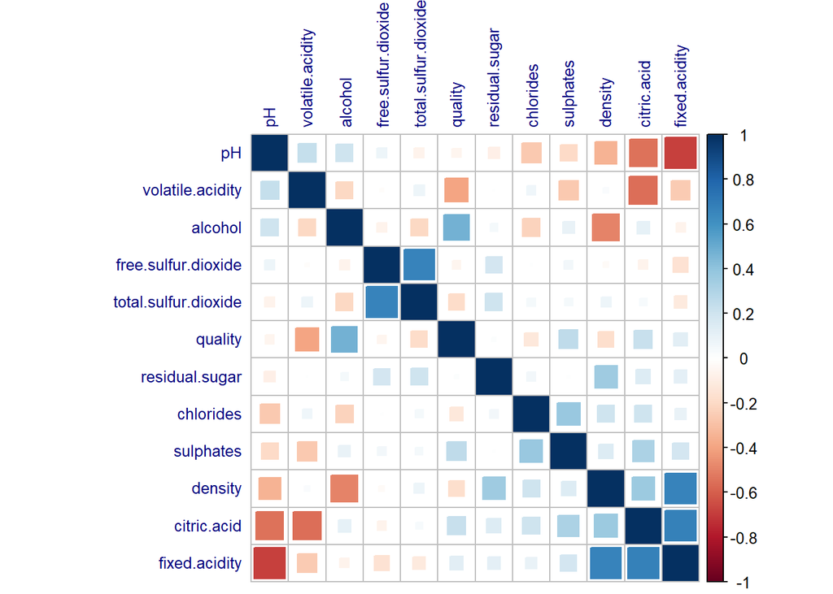

```r
# Vi negre
nc=ncol(n1)
df <- n1[,1:11]
df$quality <- as.integer(n1[,12])
correlacio <- cor(df,method="pearson")
corrplot(correlacio, number.cex = 2, method = "square", hclust.method = "ward", order = "FPC",
         type = "full", tl.cex=0.8,tl.col = "navy")
```

De la matriu anterior podem establir les següents correlacions entre atributs per el vi negre:

1. Alta correlació relativa:  
   **total.sulfur.dioxide** amb **free.sulfur.dioxide**.  
   **fixed.acidity** amb **density** i **citric.acid**.
2. Relativament correlacionades:  
   **alcohol** amb **qualitat**
3. Altament inverses correlatives  
   **fixed.acidity** amb **pH**
4. Relativament inversament correlatives:  
   **citric.acid** amb **pH** i **volatile.acidity**

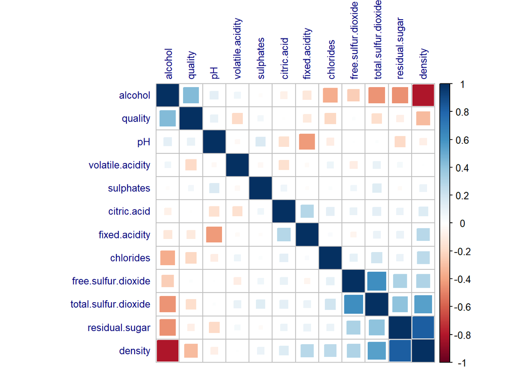

```r
# Vi blanc
nc=ncol(n2)
df <- n2[,1:11]
df$quality <- as.integer(n2[,12])
correlacio <- cor(df,method="pearson")
corrplot(correlacio, number.cex = 2, method = "square", hclust.method = "ward", order = "FPC",
         type = "full", tl.cex=0.8,tl.col = "navy")
```

De la matriu anterior podem establir les següents correlacions entre atributs per el vi blanc:

1. Alta correlació relativa:  
   **total.sulfur.dioxide** amb **free.sulfur.dioxide**.  
   **densitat** amb **residual.sugar**.
2. Relativament correlacionats:  
   **alcohol** amb **qualitat**
3. Altament inversament correlacionats  
   **densitat** amb **alcohol**
4. Relativament inversament correlacionats:  
   **alcohol** amb **residual.sugar** i **total.sulfur.dioxide** i  
   **fixed.acidity** amb **pH**